# Homework 2 Report

## Akash Rajeev

### Setup

Read in the data with `read_csv()` and store the data as an R object named `dataset`. Check the data to make sure all of the expected observations and variables are there.

```r
## Load the data and any necessary packages here.
library(dplyr)
library(ggplot2)
library(knitr)
library(data.table)
dataset = fread("maacs.csv.gz")

dataset %>%
  head(10) %>%
    kable()
```

| id | age | gender | fev1 | eNO | cough_days | pm25 | no2 | mouse | mouse_allergic |
| --- | --- | --- | --- | --- | --- | --- | --- | --- | --- |
| fd171e2d | 14.72 | male | 1.78 | 141 | 2 | 15.560 | NA | 2423 | yes |
| a66fc33a | 13.56 | female | 2.12 | 68 | 8 | 18.890 | 12.827 | 939 | yes |
| fc038e68 | 14.50 | male | 2.73 | 210 | 2 | 17.808 | NA | 200 | no |
| 8e28b8c2 | 13.96 | female | 2.36 | 23 | 0 | 13.956 | NA | NA | no |
| b2699b54 | 16.63 | female | 3.13 | 18 | 14 | 17.864 | 30.976 | 10371 | no |
| 7d4f3508 | 16.56 | female | 2.59 | 128 | 0 | 43.784 | 10.590 | 4789 | yes |
| 3d8242a6 | 17.18 | female | 2.60 | 19 | 0 | 26.313 | NA | 760 | yes |
| f401998a | 15.46 | male | 3.49 | 26 | 4 | 39.864 | 32.902 | 264 | no |
| 357fdacb | 12.68 | female | 2.29 | 17 | 1 | 27.081 | 25.659 | 419 | no |
| 2a722e16 | 16.02 | male | 2.37 | 134 | 14 | 64.578 | 17.953 | 187 | yes |

## Part 1

We will first consider the relationship between FEV1 and age. In general, it is expected that as children get older (and hence, larger in size), their FEV1 values should get higher.

Consider the statement “FEV1 values in children are higher in older children relative to younger children”.

Write a function in R that takes the `dataset` object as an argument and returns `TRUE` if the statement above is true for the dataset and `FALSE` otherwise.

NOTE: In order to write this function, you will need to translate the statement above into something that can be checked with the data. There are many ways in which you can do that translation correctly and you only need to pick one way here.

NOTE: For this part, do not use any plots.

Statement: “FEV1 values in children are higher in older children relative to younger children”

```r
agefev1 = function(x){
  average_age = mean(x$age)

  # age groups if individuals are above or below the average age
  mean_strata = x %>%
    mutate(age_strata = case_when(
    x$age > average_age ~ "older",
    x$age < average_age ~ "younger",
    x$age == average_age ~ "average")) %>%

    filter(age_strata != "average") %>%
    group_by(age_strata) %>%
    summarize(mean_fev1 = mean(fev1, na.rm = TRUE), .groups = "drop")

    # calculate averages for each age group
    older_mean = mean_strata %>% filter(age_strata == "older") %>% pull(mean_fev1)
    younger_mean = mean_strata %>% filter(age_strata == "younger") %>% pull(mean_fev1)

  return (older_mean > younger_mean)
  }

print(agefev1(dataset))
```

```
## [1] TRUE
```

## Part 2

Fit a linear regression model with FEV1 as the outcome and age as a predictor.

How much does FEV1 change for a 1-year increase in the child’s age?

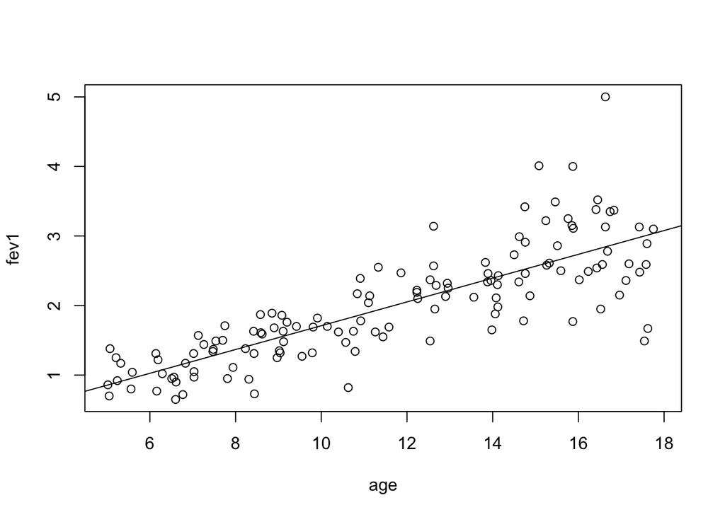

```r
model = lm(fev1 ~ age, dataset)

plot(fev1 ~ age, data = dataset)
abline(model)
```

```r
summary(model)
```

```
##
## Call:
## lm(formula = fev1 ~ age, data = dataset)
##
## Residuals:
##      Min       1Q   Median       3Q      Max
## -1.51099 -0.27100  0.00196  0.23616  2.15477
##
## Coefficients:
##              Estimate Std. Error t value Pr(>|t|)
## (Intercept) -0.001199   0.134696  -0.009    0.993
## age          0.171162   0.010984  15.583   <2e-16 ***
## ---
## Signif. codes:  0 '***' 0.001 '**' 0.01 '*' 0.05 '.' 0.1 ' ' 1
##
## Residual standard error: 0.4827 on 131 degrees of freedom
##   (17 observations deleted due to missingness)
## Multiple R-squared:  0.6496, Adjusted R-squared:  0.6469
## F-statistic: 242.8 on 1 and 131 DF,  p-value: < 2.2e-16
```

```r
coef(model)[2]
```

```
##       age
## 0.1711623
```

Write your data analysis statement interpreting the regression model here:

Since the slope is 0.1711623, we can interpret that for every 1 year increase in age, we may observe an increase of 0.1711623 in fev1 value.

## Part 3

Develop **three** supporting premises derived from the data that support the statement you wrote in Part 2. These can be plots, other summary statistics, or model results.

NOTE: At least one supporting premise should use a plot.

### 1 – Scatterplot

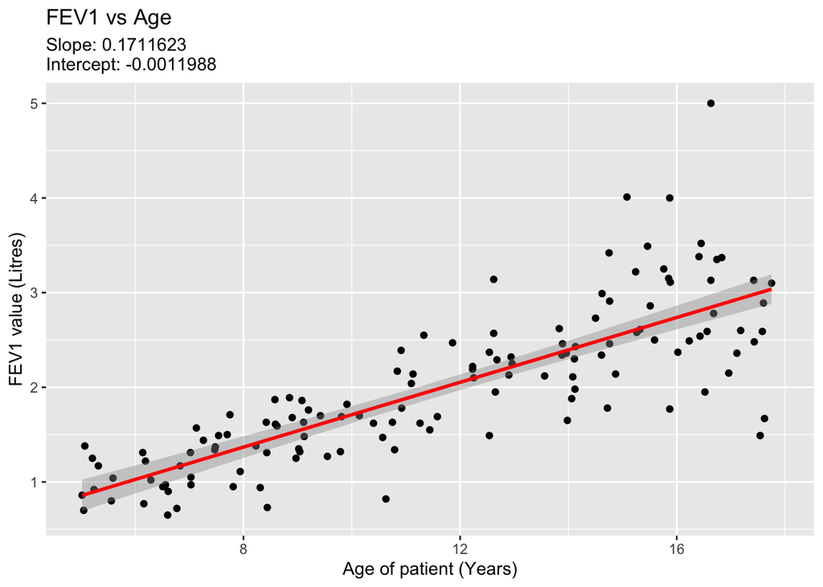

```r
# plot scatterplot
ggplot(dataset, aes(x = age, y = fev1)) +
         geom_point() +
         geom_smooth(method = "lm", col = "red") +
         labs( x = "Age of patient (Years)", y = "FEV1 value (Litres)",  subtitle = paste0("Slope: ", round(coef(model)[2], 7), "\nIntercept: ", round(coef(model)[1], 7))) +
         ggtitle("FEV1 vs Age")
```

### 2 – Correlation Test

```r
cor_agefev1 = cor.test(dataset$age, dataset$fev1)
print(cor_agefev1)
```

```
##
##  Pearson's product-moment correlation
##
## data:  dataset$age and dataset$fev1
## t = 15.583, df = 131, p-value < 2.2e-16
## alternative hypothesis: true correlation is not equal to 0
## 95 percent confidence interval:
##  0.7368348 0.8584229
## sample estimates:
##       cor
## 0.8059696
```

### 3 – Boxplot

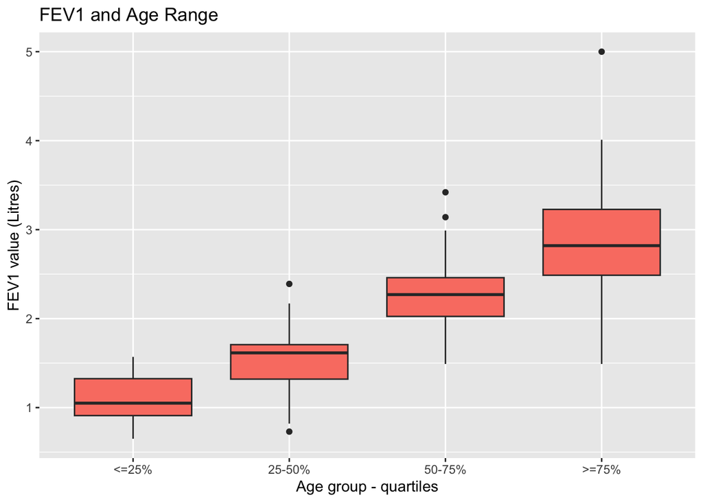

```r
dataset %>%
  mutate(age_group = ntile(age, 4)) %>%
  ggplot(aes(x = factor(age_group, labels = c("<=25%", "25-50%", "50-75%", ">=75%")), y = fev1)) +
  geom_boxplot(fill = "salmon") +
  labs(x = "Age group - quartiles", y = "FEV1 value (Litres)") +
  ggtitle("FEV1 and Age Range")
```

Write the three supporting premise statements here:

##### 1. A scatterplot of FEV1 vs. age reveals a positive trend, indicating that as age increases, so does FEV1 value. This direct relationship is further substantiated by the slope and intercept of a best-fit line through the data, which can represent a slope of roughly 0.171, supporting the idea that as age increases, so does FEV1 in the patients.

##### 2. The correlation test may indicate the strength of the association between the variables age and FEV1. When performing this test on these variables, the r value is noted to be roughly 0.806, with a p-value of roughly 0, and a confidence interval of roughly (0.737, 0.858). This may indicate a somewhat strong, statistically significant positive correlation between age and FEV1. This positive correlation supports the premise that as age increases, so does FEV1.

##### 3. The boxplots may demonstrate that median FEV1 values may increase across successive age groups, consistent with the regression slope, and the notion that as age increases, so do FEV1 values.

## Part 4

For each of the supporting premises above, write a function that takes the `dataset` object as an argument and returns `TRUE` if the supporting premise statement above is true for the dataset and `FALSE` otherwise.

For statements involving plots, instead of returning `TRUE` or `FALSE`, you function should do two things:

1. Produce the plot that is used in the statement
2. Produce a hypothetical version of the plot in the event that the statement is true. This can be done using simulated data or by simply hand drawing a plot.

Execute each of your function and show that the produce the expected output.

### Supporting Premise 1 Function

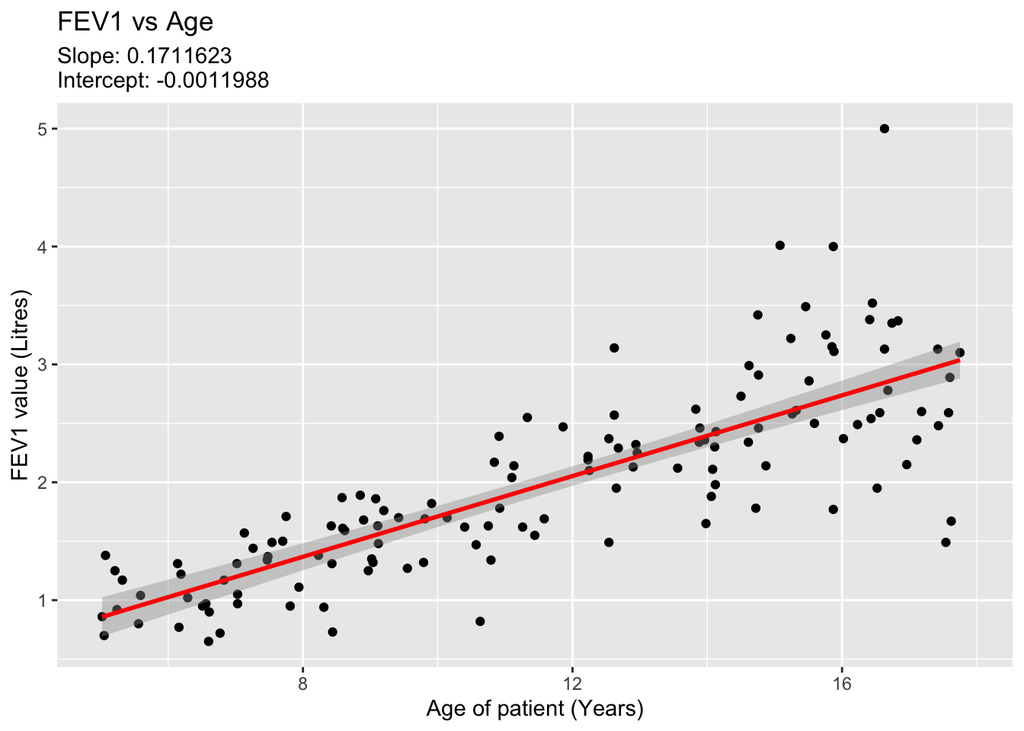

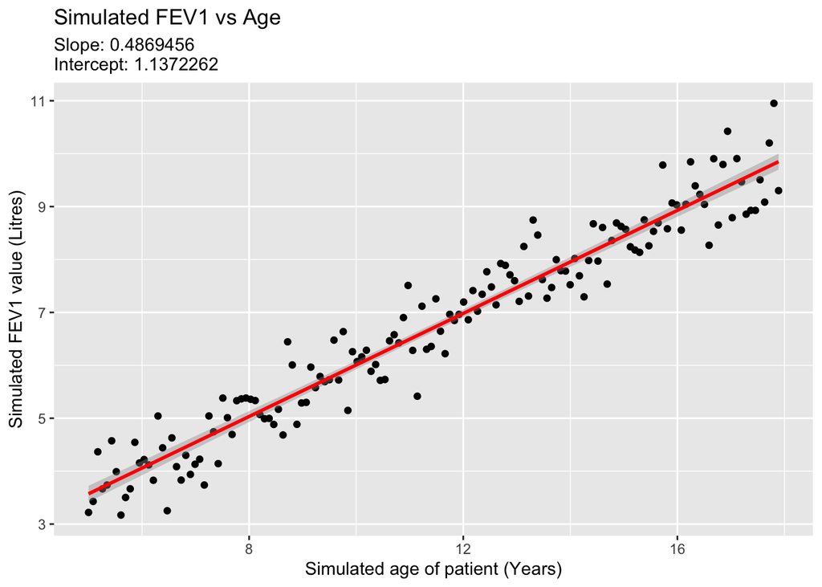

```r
premise1 = function(x){
  set.seed(123)

  # Produce plot used in the statement:

  p1_plot = ggplot(x, aes(x = age, y = fev1)) +
         geom_point() +
         geom_smooth(method = "lm", col = "red") +
         labs( x = "Age of patient (Years)", y = "FEV1 value (Litres)",  subtitle = paste0("Slope: ", round(coef(model)[2], 7), "\nIntercept: ", round(coef(model)[1], 7))) +
         ggtitle("FEV1 vs Age")

  # Generate simulated data

  age_sim = seq(min(x$age), max(x$age), length.out = nrow(x))
  fev1_sim = 0.5 + 0.5 * age_sim + rnorm(nrow(x), 0.5, 0.5)
  sim_data = data.frame(age = age_sim, fev1 = fev1_sim)
  sim_model = lm(fev1 ~ age, sim_data)

  # Plot simulated data

  p1_sim_plot = ggplot(sim_data, aes(x = age_sim, y = fev1_sim)) +
         geom_point() +
         geom_smooth(method = "lm", col = "red") +
         labs( x = "Simulated age of patient (Years)", y = "Simulated FEV1 value (Litres)",  subtitle = paste0("Slope: ", round(coef(sim_model)[2], 7), "\nIntercept: ", round(coef(sim_model)[1], 7))) +
         ggtitle("Simulated FEV1 vs Age")

  return(list(p1_plot, p1_sim_plot))
}

p1 = premise1(dataset)

p1
```

### Supporting Premise 2 Function

```r
premise2 = function(x){
  cor_test = cor.test(x$age, x$fev1)
  return(cor_test$estimate > 0 & cor_test$p.value < 0.05)
}

p2 = premise2(dataset)

p2
```

```
##  cor
## TRUE
```

### Supporting Premise 3 Function

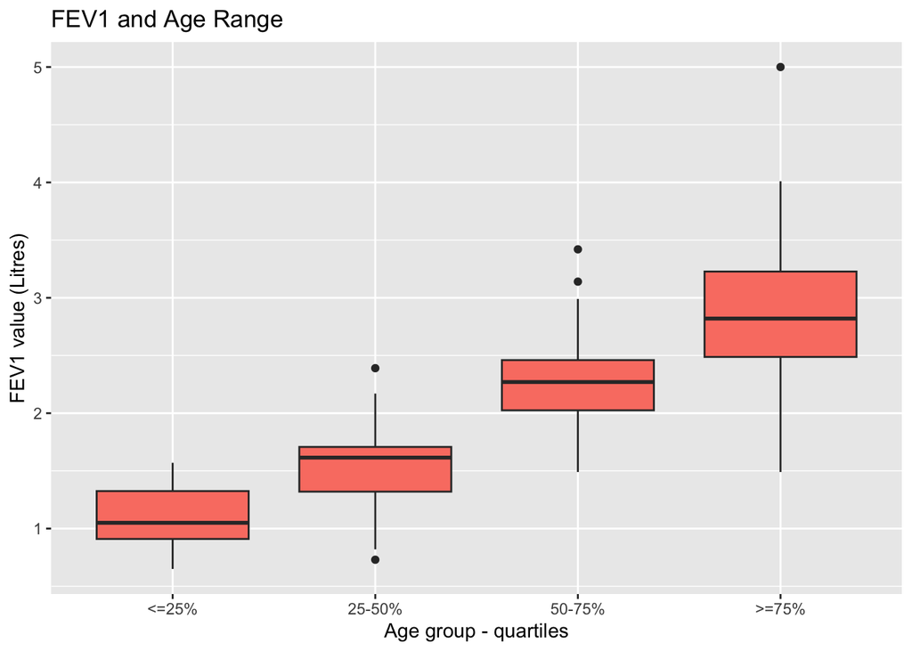

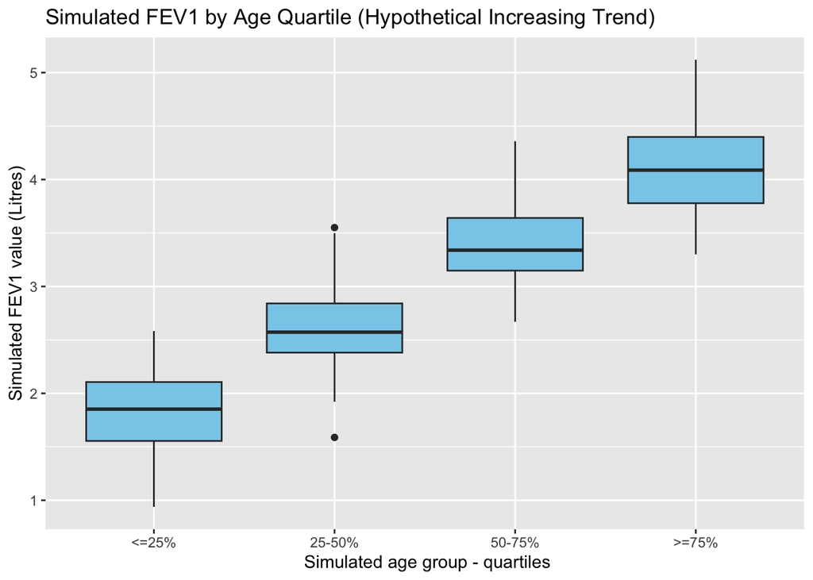

```r
premise3 = function(x){

  # Produce plot used in the statement:

  p3_actual = x %>%
    mutate(age_group = ntile(age, 4)) %>%
    ggplot(aes(x = factor(age_group, labels = c("<=25%", "25-50%", "50-75%", ">=75%")), y = fev1)) +
    geom_boxplot(fill = "salmon") +
    labs(x = "Age group - quartiles", y = "FEV1 value (Litres)") +
    ggtitle("FEV1 and Age Range")


  # Generate simulated data
  set.seed(123)
  n = nrow(x)
  actual_quartile_data = x %>%
  mutate(age_group = ntile(age, 4)) %>%
  group_by(age_group) %>%
  summarize(sd_fev1 = sd(fev1, na.rm = TRUE), .groups = "drop")

  actual_sd = mean(actual_quartile_data$sd_fev1, na.rm = TRUE)

  n_per_group = n %/% 4
  remainder = n %% 4

  # age groups roughly equal sizes
  gr = c(rep(1, n_per_group + (remainder >= 1)),
         rep(2, n_per_group + (remainder >= 2)),
         rep(3, n_per_group + (remainder >= 3)),
         rep(4, n_per_group))

  fev1_sim = c()
  for(i in 1:4) {
    group_size = sum(gr == i)
    fev1_sim = c(fev1_sim, rnorm(group_size, mean = 1.0 + i * 0.8, sd = actual_sd))
  }


  sim_data = data.frame(
    age_group = factor(gr, labels = c("<=25%", "25-50%", "50-75%", ">=75%")),
    fev1 = fev1_sim)

  # plot simulated data


  p3_hyp = ggplot(sim_data, aes(x = age_group, y = fev1)) +
    geom_boxplot(fill = "skyblue") +
    labs(x = " Simulated age group - quartiles", y = "Simulated FEV1 value (Litres)") +
    ggtitle("Simulated FEV1 by Age Quartile (Hypothetical Increasing Trend)")


  return(list(p3_actual, p3_hyp))
}
p3 = premise3(dataset)

p3
```

## Part 5

Describe one alternative to the primary statement “FEV1 values in children are higher in older children relative to younger children”.

Create a fault tree for the alternative outcome describing how the alternative outcome could be realized in the data even if the primary statement were true.

Your fault tree should be created as a separate image and does not need to be created in R. Upload the image of the fault tree to Canvas.